# AEEM 3062

# HOMEWORK # 4

# 2022-2023 SPRING

### Name: Slade Brooks

### M#: 13801712

### DUE: 11.59 PM on 2/9/2023

## Problem 1

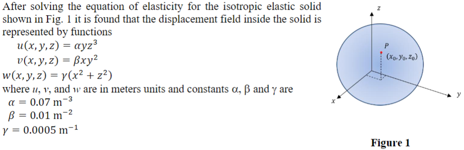

### Part A

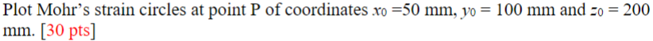

First we need to find the strain tensor given by: $$ \hat\sigma = \begin{bmatrix} \frac{\partial u}{\partial x} & \frac{1}{2}(\frac{\partial u}{\partial y}+\frac{\partial v}{\partial x}) & \frac{1}{2}(\frac{\partial u}{\partial z}+\frac{\partial w}{\partial x}) \\ & \frac{\partial v}{\partial y} & \frac{1}{2}(\frac{\partial v}{\partial z}+\frac{\partial w}{\partial y}) \\ sym & & \frac{\partial w}{\partial z} \end{bmatrix} $$

By calculating the partials of the given equations for $u, v,$ and $w$ and substituting we get the strain tensor for this problem:

$$ \hat\sigma = \begin{bmatrix} 0 & \frac{1}{2}(\alpha z^{3}+\beta y^{2}) & \frac{1}{2}(3\alpha yz^{2}+2\gamma x) \\ & 2\beta xy & 0 \\ sym & & 2\gamma z \end{bmatrix} $$

Then by substituting in the constants $\alpha=0.07$, $\beta=0.01$, $\gamma=0.0005$ and $\\$ conditions $x_{0}=0.05$ m, $y_{0}=0.1$ m, $z_{0}=0.2$ m gives the fully filled out strain tensor: $$ \hat\sigma = \begin{bmatrix} 0 & 3.3E-4 & 4.45E-4 \\ 3.3E-4 & 1E-4 & 0 \\ 4.45E-4 & 0 & 2E-4 \end{bmatrix} $$

Using Matlab's eig() function we can find the eigenvalues of the strain tensor which $\\$ are the principle strains and correspond to the points of the Mohr's circles.

$$ \begin{bmatrix} \epsilon_{1} & 0 & 0\\0 & \epsilon_{2} & 0\\0 & 0 & \epsilon_{3} \end{bmatrix} = \begin{bmatrix} -4.794E-4 & 0 & 0 \\ 0 & 1.345E-4 & 0 \\ 0 & 0 & 6.449E-4 \end{bmatrix} $$

Then we plot these points on a graph. Then, the Mohr's circles are plotted. This is done by plotting one circle with a diameter from $\epsilon_{1}$ to $\epsilon_{3}$, one from $\epsilon_{1}$ to $\epsilon_{2}$, and one from $\epsilon_{2}$ to $\epsilon_{3}$.

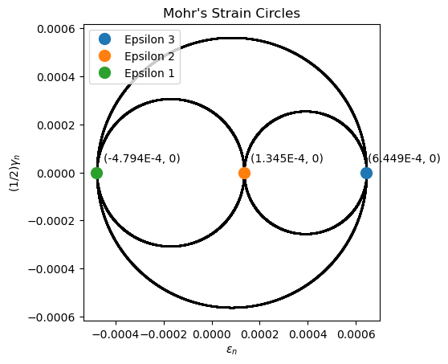

### Part B

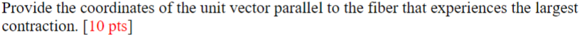

$$ \fbox{$\begin{bmatrix} 0.7552 \\ -0.4301 \\ -0.4946 \end{bmatrix}$} $$

### Part C

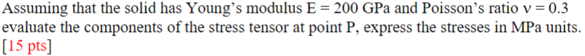

The stress tensor is related to the stress tensor by the stiffness matrix:

$$ \begin{bmatrix} \sigma_{xx} \\ \sigma_{yy} \\ \sigma_{zz} \\ \tau_{xy} \\ \tau_{xz} \\ \tau_{yz} \end{bmatrix} = \begin{bmatrix} A & B & B & & \\ B & A & B & & 0 & \\ B & B & A & & \\ & & & G & 0 & 0 \\ & 0 & & 0 & G & 0 \\ & & & 0 & 0 & G \end{bmatrix} \begin{bmatrix} \epsilon_{xx} \\ \epsilon_{yy} \\ \epsilon_{zz} \\ \gamma_{xy} \\ \gamma_{xz} \\ \gamma_{yz} \end{bmatrix} $$

The stiffness matrix has components:

$$ A = \frac{E(1-v)}{(1-2v)(1+v)}, \quad B = \frac{Ev}{(1-2v)(1+v)}, \quad G = \frac{E}{2(1+v)} $$

We can plug in the values of E and v into A, B, and G, and then plug those into the stiffness matrix.

$A = 269.23$ GPa $= 269,230$ MPa, $\quad B = 115.385$ GPa $= 115,385$ MPa, $\quad G = 76.923$ GPa $= 76,923$ MPa

We can also plug in the values for $\epsilon$ and $\gamma$, with the $\gamma$ terms all being multiplied by 2 since in the strain tensor they are given as $\frac{1}{2} \gamma$.

$$ \begin{bmatrix} \sigma_{xx} \\ \sigma_{yy} \\ \sigma_{zz} \\ \tau_{xy} \\ \tau_{xz} \\ \tau_{yz} \end{bmatrix} = \begin{bmatrix} 269230 & 115385 & 115385 & 0 & 0&0 \\ 115385 & 269230 & 115385 & 0 & 0 &0 \\ 115385 & 115385 & 269230 &0 & 0& 0\\ 0 & 0 & 0 & 76923 & 0 & 0 \\ 0&0&0& 0 & 76923 & 0 \\ 0&0&0&0&0 & 76923 \end{bmatrix} \begin{bmatrix} 0 \\ 1E-4 \\ 2E-4 \\ 2(3.3E-4) \\ 2(4.45E-4) \\ 0 \end{bmatrix} $$

Using Matlab's matrix multiplication, we can solve for the stress tensor:

$$ \fbox{$\begin{bmatrix} \sigma_{xx} \\ \sigma_{yy} \\ \sigma_{zz} \\ \tau_{xy} \\ \tau_{xz} \\ \tau_{yz} \end{bmatrix} = \begin{bmatrix} 34.616 \\ 50.0 \\ 65.3845 \\ 50.7692 \\ 68.4615 \\ 0 \end{bmatrix} MPa $} $$

### Part D

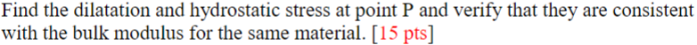

First we can calculate dilatation from the $\epsilon$ values.

$$ \delta = \epsilon_{xx} + \epsilon_{yy} + \epsilon_{zz} = 0 + 1E-4 + 2E-4 = 3E-4 $$

Then we can calculate hydrostatic stress from the $\sigma$ values.

$$ \sigma_{h} = \frac{\sigma_{xx}+\sigma_{yy}+\sigma_{zz}}{3} = \frac{34.616+50.0+65.3845}{3} = 50.0 MPa $$

Then we can calculate the bulk modulus using the dilatation and hydrostatic stress.

$$ K = \frac{\sigma_{h}}{\delta} = \frac{50.0}{3E-4} = 166666.6667 MPa $$

Then we can calculate K from the E and v values given for the equation.

$$ K = \frac{E}{3(1-2v)} = \frac{200000}{3(1-2(0.3))} = 166666.6667 MPa $$

We can see that the bulk modulus from our calculated values and the bulk modulus from the given material properties are consistent.

## Problem 2

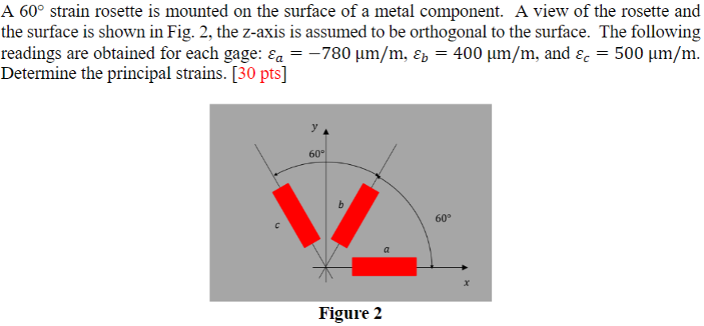

To solve for the principle strains we will use the equation:

$$ \epsilon_{n} = \epsilon_{xx}\cos^{2}{\theta} + \epsilon_{yy}\sin^{2}{\theta} + \gamma_{xy}\sin{\theta}\cos{\theta} $$

We can substitute each $\epsilon$ (a, b, and c)'s values and angle into this equation to create a system of equations we can solve for the principle strains.

$$ \epsilon_{a} = \epsilon_{xx}\cos^{2}{0} + \epsilon_{yy}\sin^{2}{0} + \gamma_{xy}\sin{0}\cos{0} = -780 \\ \epsilon_{b} = \epsilon_{xx}\cos^{2}{60} + \epsilon_{yy}\sin^{2}{60} + \gamma_{xy}\sin{60}\cos{60} = 400 \\ \epsilon_{c} = \epsilon_{xx}\cos^{2}{120} + \epsilon_{yy}\sin^{2}{120} + \gamma_{xy}\sin{120}\cos{120} = 500 $$

Solving the angles gives us much simpler equations:

$$ \epsilon_{a} = \quad \fbox{$\epsilon_{xx} = -780$} \\ \epsilon_{b} = 0.25\epsilon_{xx} + 0.75\epsilon_{yy} + 0.433013\gamma_{xy} = 400 \\ \epsilon_{c} = 0.25\epsilon_{xx} + 0.75\epsilon_{yy} - 0.433013\gamma_{xy} = 500 $$

Then we know that $\epsilon_{xx}=-780$ so we can plug that in to the other equations. The $\gamma_{xy}$ values conveniently cancel so we can combine the equations to get one in only terms of $\epsilon_{yy}$:

$$ -390 + 1.5\epsilon_{yy} = 900, \quad \fbox{$\epsilon_{yy} = 860$} $$

Lastly, we can plug in and solve for $\gamma_{xy}$.

$$ 0.25(-780)+0.75(860)+0.433013\gamma_{xy} = 400, \quad \fbox{$\gamma_{xy} = -115.47$} $$